# Lesson I. R language Programming Environment

Ruth Gómez Graciani

2017/10/16

#### 1 - Create a vector called v and assign the values (3.14, 123, 0.01)

```r
v <- c(3.14, 123,   0.01)
v
```

```
## [1]   3.14 123.00   0.01
```

#### 2- Create a new vector that stores three values: v, 123 and v

```r
a <- c(v, 123, v)
a
```

```
## [1]   3.14 123.00   0.01 123.00   3.14 123.00   0.01
```

#### 3- Calculate the square root of vector v and store it in a new varieble

```r
my_sqrt<-sqrt(v)
my_sqrt
```

```
## [1]  1.772005 11.090537  0.100000
```

#### 4- Now calculate the value of v divided by my_sqrt

```r
v/my_sqrt
```

```
## [1]  1.772005 11.090537  0.100000
```

#### 5- Add this two vectors: (1, 2, 3, 4) and (0,100). What do you see? Can two vectors of different length be added?

```r
c(1,2,3,4) + c(0,100)
```

```
## [1]   1 102   3 104
```

Yes, they can, because the largest vector is a multiple from the smaller one. The small vector is repeated twice in order to add it to the first one.

#### 6- Create a sequence of numbers from 1 to 19 using the : operator

```r
1:19
```

```
##  [1]  1  2  3  4  5  6  7  8  9 10 11 12 13 14 15 16 17 18 19
```

#### 7- Now use seq() to create a sequence from 1 to 10 incrementing by 0.5

```r
seq(1,10,0.5)
```

```
##  [1]  1.0  1.5  2.0  2.5  3.0  3.5  4.0  4.5  5.0  5.5  6.0  6.5  7.0  7.5
## [15]  8.0  8.5  9.0  9.5 10.0
```

#### 8- Use seq() to generate a list of 50 numbers between 50 and 999 and store the list in a variable n

```r
n<-seq(50, 999, length.out = 50)
n
```

```
##  [1]  50.00000  69.36735  88.73469 108.10204 127.46939 146.83673 166.20408
##  [8] 185.57143 204.93878 224.30612 243.67347 263.04082 282.40816 301.77551
## [15] 321.14286 340.51020 359.87755 379.24490 398.61224 417.97959 437.34694
## [22] 456.71429 476.08163 495.44898 514.81633 534.18367 553.55102 572.91837
## [29] 592.28571 611.65306 631.02041 650.38776 669.75510 689.12245 708.48980
## [36] 727.85714 747.22449 766.59184 785.95918 805.32653 824.69388 844.06122
## [43] 863.42857 882.79592 902.16327 921.53061 940.89796 960.26531 979.63265
## [50] 999.00000
```

#### 9- Apply the length() function to the variable n. Which is the result?

```r
length(n)
```

```
## [1] 50
```

The result is the number of elements inside the vector

#### 10- Now generate a new list of numbers starting from 1 that has the same length as n variable

```r
b<-list(1:length(n))
b
```

```
## [[1]]
##  [1]  1  2  3  4  5  6  7  8  9 10 11 12 13 14 15 16 17 18 19 20 21 22 23
## [24] 24 25 26 27 28 29 30 31 32 33 34 35 36 37 38 39 40 41 42 43 44 45 46
## [47] 47 48 49 50
```

#### 11- Create a vector with 100 zeros

```r
c<-rep(0, 100)
c
```

```
##   [1] 0 0 0 0 0 0 0 0 0 0 0 0 0 0 0 0 0 0 0 0 0 0 0 0 0 0 0 0 0 0 0 0 0 0 0
##  [36] 0 0 0 0 0 0 0 0 0 0 0 0 0 0 0 0 0 0 0 0 0 0 0 0 0 0 0 0 0 0 0 0 0 0 0
##  [71] 0 0 0 0 0 0 0 0 0 0 0 0 0 0 0 0 0 0 0 0 0 0 0 0 0 0 0 0 0 0
```

#### 12- Create a new vector with 10 repetitions of the vector (“a”, “b”, “c”)

```r
d<-rep(c('a', 'b', 'c'), 10)
d
```

```
##  [1] "a" "b" "c" "a" "b" "c" "a" "b" "c" "a" "b" "c" "a" "b" "c" "a" "b"
## [18] "c" "a" "b" "c" "a" "b" "c" "a" "b" "c" "a" "b" "c"
```

#### 13- Now create a new vector that contains 10 a letters, then 10 b’s, then 10 c’s and save it into a variable called abc

```r
abc<-c(rep('a',10),rep('b',10),rep('c',10))
abc
```

```
##  [1] "a" "a" "a" "a" "a" "a" "a" "a" "a" "a" "b" "b" "b" "b" "b" "b" "b"
## [18] "b" "b" "b" "c" "c" "c" "c" "c" "c" "c" "c" "c" "c"
```

#### 14- Create a vector with the values (1,100,-25,365) and save it into v1 variable

```r
v1<-c(1,100,-25,365)
v1
```

```
## [1]   1 100 -25 365
```

#### 15- now create a new variable bool that gets the result of v1<1. What is the result of this operation? What kind of value you see?

```r
bool<-v1<1
bool
```

```
## [1] FALSE FALSE  TRUE FALSE
```

The result of the operation is TRUE when the inequality is accomplished, and FALSE when not, for each value of the vector. The value is a logical operator, as we can see when the str functions is used

```r
str(bool)
```

```
##  logi [1:4] FALSE FALSE TRUE FALSE
```

#### 16- Now take abc variable from question 13 and generate a single string value. That is, something like: (a,b,c) -> “abc”

```r
abc<-paste(abc, collapse="")
abc
```

```
## [1] "aaaaaaaaaabbbbbbbbbbcccccccccc"
```

#### 17- Create a new matrix with 4 rows and 5 columns from a new vector that contains the values from 1 to 20. Store the results in variable m1

```r
e<-c(1:20)
m1<-matrix(e, 4,5)
m1
```

```
##      [,1] [,2] [,3] [,4] [,5]
## [1,]    1    5    9   13   17
## [2,]    2    6   10   14   18
## [3,]    3    7   11   15   19
## [4,]    4    8   12   16   20
```

#### 18- Now create a vector called students with the values (“Ana”,“John”,“Pedro”,“Joan”) and create a new matrix adding students as a new column to m1 matrix. What happens to numeric values?

```r
names<-c ("Ana","John","Pedro","Joan")
m2<-matrix(c(m1,names),4,6)
m2
```

```
##      [,1] [,2] [,3] [,4] [,5] [,6]
## [1,] "1"  "5"  "9"  "13" "17" "Ana"
## [2,] "2"  "6"  "10" "14" "18" "John"
## [3,] "3"  "7"  "11" "15" "19" "Pedro"
## [4,] "4"  "8"  "12" "16" "20" "Joan"
```

The numerical values have been converted into characters

#### 19- Now create a new data.frame() called df with students vector and m1 matrix. What difference do you see with the previous matrix?

```r
df<-data.frame(m1, names)
df
```

```
##   X1 X2 X3 X4 X5 names
## 1  1  5  9 13 17   Ana
## 2  2  6 10 14 18  John
## 3  3  7 11 15 19 Pedro
## 4  4  8 12 16 20  Joan
```

The data frame can contain different value types

#### 20- create a new vector with the labels “name”, “age”, “weight”, “bp”, “rate”, “test”. Now use colnames() to set the colnames attribute of our data frame df. Show your final data frame

```r
labels<-c("name",   "age", "weight",    "bp",    "rate",    "test")
colnames(df)<-labels
df
```

```
##   name age weight bp rate  test
## 1    1   5      9 13   17   Ana
## 2    2   6     10 14   18  John
## 3    3   7     11 15   19 Pedro
## 4    4   8     12 16   20  Joan
```

#### 21- Calculate the mean of a vector with values (10,11,12)

```r
f<-c(10,11,12)
mean(f)
```

```
## [1] 11
```

#### 22- Now create a new function call new_mean that receives a vector as a parameter, then calculates the sum of the vector, the length of the vector and return the mean of the vector.

```r
new_mean<- function(vector){
  summatory<-sum(vector)
  numofels<-length(vector)
  return(summatory/numofels)
}

new_mean(f)
```

```
## [1] 11
```

#### 23- Use sample() function to simulate a rolling dice. That is, randomly select four numbers between 1 and 6 with replacement.

```r
sample(1:6,4,replace = T)
```

```
## [1] 1 2 1 6
```

#### 24- Simulate 50 flips of an unfair two-sided coin. The probabilities here are 0.7 for heads and 0.3 for tails. Use sample() to draw a sample of size 50. Store the results in variable flip. How would you test if the results follow the probability defined?

```r
coin<-c('heads', 'tails')
prob<-c(0.7,0.3)
flip<-sample(coin, 50, prob, replace = T)
table(flip)/50
```

```
## flip
## heads tails
##  0.74  0.26
```

The table function counts the number of elements inside the vector, and dividing it by the total number of elements we obtain the proportion or probability.

#### 25- How would you generate 10 random numbers from a standard normal distribution with a mean of 150 and a standard deviation of 10?

```r
rnorm(10, 150, 10)
```

```
##  [1] 134.4452 148.7874 143.2995 132.6791 139.7255 150.2399 148.9331
##  [8] 147.1954 156.7087 154.8368
```

#### 26- Now, how would you generate 100 sets of random numbers like the previous question? Save results in a variable called rp

```r
rp<-matrix(nrow = 10, ncol = 100)

for(i in c(1:100)){
  rp[,i]<-rnorm(10, 150, 10)
}
```

The variable rp is partially below:

```r
rp[,1:8]
```

```
##           [,1]     [,2]     [,3]     [,4]     [,5]     [,6]     [,7]
##  [1,] 147.7257 138.9953 150.1969 142.8916 155.4266 163.3030 154.4621
##  [2,] 152.9471 134.5884 166.0525 166.7347 158.0398 143.3461 142.1707
##  [3,] 154.3330 138.7364 148.5319 150.5886 137.2409 152.6946 155.9580
##  [4,] 142.6901 143.0420 138.7067 146.8739 161.9077 134.7456 156.2512
##  [5,] 145.5268 149.2138 148.7074 153.5475 168.0404 122.3123 152.8786
##  [6,] 162.4389 148.8556 170.8327 174.5794 170.2462 164.6393 143.1336
##  [7,] 146.2216 144.2375 153.4384 160.4155 160.7948 154.0373 144.0331
##  [8,] 133.7096 153.6490 167.7454 163.0279 137.0129 165.5790 154.6477
##  [9,] 144.7579 143.8435 142.9383 153.0804 152.4611 165.1652 140.4791
## [10,] 156.5661 164.9206 160.0357 152.6979 135.5618 157.8725 164.6124
##           [,8]
##  [1,] 161.8844
##  [2,] 141.4355
##  [3,] 156.7175
##  [4,] 153.4573
##  [5,] 151.3018
##  [6,] 145.1141
##  [7,] 140.6416
##  [8,] 142.8565
##  [9,] 145.9150
## [10,] 158.3164
```

#### 27- Use colMeans() function to find the mean of each column of rp and plot a histogram

```r
g<-colMeans(rp)
g
```

```
##   [1] 148.6917 146.0082 154.7186 156.4437 153.6732 152.3695 150.8627
##   [8] 149.7640 146.4460 148.4556 148.1223 153.5510 151.8969 146.9459
##  [15] 153.5481 147.7446 150.2007 148.2574 154.3146 151.5198 144.4666
##  [22] 142.6011 150.0353 145.4039 150.4611 149.8145 152.6725 155.2386
##  [29] 154.2679 152.4664 151.4935 144.4496 153.8000 152.1614 146.6206
##  [36] 151.8752 150.7484 150.7973 146.6182 150.1165 150.7876 147.2986
##  [43] 146.9817 147.0867 152.8054 147.4378 150.0001 147.2682 144.1338
##  [50] 150.4156 144.8334 155.3644 149.0293 151.4480 154.6139 152.9750
##  [57] 153.2792 155.5057 151.6175 157.4028 148.8697 150.5394 152.5804
##  [64] 143.4073 149.1637 157.1552 148.3162 149.7326 152.0116 153.7436
##  [71] 150.6441 153.3688 146.8945 149.4907 153.7599 148.1999 153.2642
##  [78] 151.9809 156.3249 148.9933 151.0637 151.7253 156.1342 153.5488
##  [85] 147.3681 153.4838 156.4979 150.3847 147.8114 148.9336 147.7489
##  [92] 148.2350 153.0706 149.7527 147.6599 157.3155 148.1284 149.7727
##  [99] 151.3664 150.3462
```

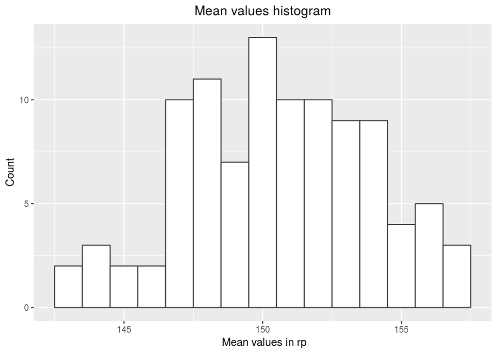

```r
ggplot() + aes(g)+ geom_histogram(binwidth=1, colour="#413839", fill="white")+labs(title="Mean values histogram", x = " Mean values in rp", y = "Count" )+theme(plot.title = element_text(hjust = 0.5))
```

#### 28- Create a vector X with 10 values and calculate the cumulative sums for this vector using a for loop.

```r
X<-sample(100, 10)
X
```

```
##  [1] 94 41 47 92 68 51 78 26 38 95
```

```r
for (i in c(2:length(X)) ){
  X[i]<-X[i]+X[i-1]
}
X
```

```
##  [1]  94 135 182 274 342 393 471 497 535 630
```

#### 29- Create two vectors, Z1 and Z2. Z1 is a vector of 20 elements filled with 20 random numbers from a standard normal distribution. Z2 is a string of 20 zeros. Design a for loop that counts from 1 to 20. For each value, it has to evaluate if the value is greater than 0. For all those values, it must write a 1 in the same position of the vector Z2. For lower than 0 values it must write a -1. Is it possible to do the same thing using which()? How would you do it?

With the for loop

```r
Z1<-rnorm(20)
Z2<-rep(0,20)
for (i in c(1:20)){
  if (Z1[i]>0){
    Z2[i]<-1
  }else{
    Z2[i]<- -1
    }
}
```

With which()

```r
Z2<-rep(0,20)
Z2[which(Z1 >0)]<-1
Z2[which(Z1 <0)]<- -1
```

#### 30- Now we are going to import a data file:plants.csv and use read.table()function to store the new table in an object called plants

```r
plants<-read.table("/media/masterbio/BIOINFO/BIOINFORMATICS/MODULE_1/R/plants2017_10_13D19_4_42 (1).csv", sep = ",")
```

#### 31- How do you find the rows and columns of the variable plants? And the size in bytes?

As we can see below, there is a large number of rows:

```r
nrow(plants)
```

```
## [1] 5166
```

```r
ncol(plants)
```

```
## [1] 10
```

A small subset of the row names will be displayed. All the column names will be displayed

```r
rownames(plants)[1:10]
```

```
##  [1] "1"  "2"  "3"  "4"  "5"  "6"  "7"  "8"  "9"  "10"
```

```r
colnames(plants)
```

```
##  [1] "Scientific_Name"      "Duration"             "Active_Growth_Period"
##  [4] "Foliage_Color"        "pH_Min"               "pH_Max"
##  [7] "Precip_Min"           "Precip_Max"           "Shade_Tolerance"
## [10] "Temp_Min_F"
```

The size in bytes:

```r
object.size(plants)
```

```
## 933520 bytes
```

#### 32- How would you see the first rows of the experiment?

```r
head(plants)
```

```
##                Scientific_Name          Duration Active_Growth_Period
## 1                  Abelmoschus              <NA>                 <NA>
## 2       Abelmoschus esculentus Annual, Perennial                 <NA>
## 3                        Abies              <NA>                 <NA>
## 4               Abies balsamea         Perennial    Spring and Summer
## 5 Abies balsamea var. balsamea         Perennial                 <NA>
## 6                     Abutilon              <NA>                 <NA>
##   Foliage_Color pH_Min pH_Max Precip_Min Precip_Max Shade_Tolerance
## 1          <NA>     NA     NA         NA         NA            <NA>
## 2          <NA>     NA     NA         NA         NA            <NA>
## 3          <NA>     NA     NA         NA         NA            <NA>
## 4         Green      4      6         13         60        Tolerant
## 5          <NA>     NA     NA         NA         NA            <NA>
## 6          <NA>     NA     NA         NA         NA            <NA>
##   Temp_Min_F
## 1         NA
## 2         NA
## 3         NA
## 4        -43
## 5         NA
## 6         NA
```

#### 33- What information is summary() providing when applied to the experiment variable? What NA plants$Precip_Minmeans? What information is str() providing?

summary() shows basic statistical values of the vector. In this case, I have assumed that one of the experiment variables is pH_Min.

```r
summary(plants$pH_Min)
```

```
##    Min. 1st Qu.  Median    Mean 3rd Qu.    Max.    NA's
##   3.000   4.500   5.000   4.997   5.500   7.000    4327
```

NA states fot Not Available (it is missing data)

str() provides the type of variable and the elements that can be found inside it. As an example, we can see that str is a datagfarme and therefore it can contain different types of values.

```r
str(plants)
```

```
## 'data.frame':    5166 obs. of  10 variables:
##  $ Scientific_Name     : Factor w/ 5166 levels "Abelmoschus",..: 1 2 3 4 5 6 7 8 9 10 ...
##  $ Duration            : Factor w/ 8 levels "Annual","Annual, Biennial",..: NA 4 NA 7 7 NA 1 NA 7 7 ...
##  $ Active_Growth_Period: Factor w/ 8 levels "Fall, Winter and Spring",..: NA NA NA 4 NA NA NA NA 4 NA ...
##  $ Foliage_Color       : Factor w/ 6 levels "Dark Green","Gray-Green",..: NA NA NA 3 NA NA NA NA 3 NA ...
##  $ pH_Min              : num  NA NA NA 4 NA NA NA NA 7 NA ...
##  $ pH_Max              : num  NA NA NA 6 NA NA NA NA 8.5 NA ...
##  $ Precip_Min          : int  NA NA NA 13 NA NA NA NA 4 NA ...
##  $ Precip_Max          : int  NA NA NA 60 NA NA NA NA 20 NA ...
##  $ Shade_Tolerance     : Factor w/ 3 levels "Intermediate",..: NA NA NA 3 NA NA NA NA 2 NA ...
##  $ Temp_Min_F          : int  NA NA NA -43 NA NA NA NA -13 NA ...
```

#### 34- Create a function to calculate the minimum Temp_Min_F and the average Precip_Min of the table plants

There are already functions to calculate the minimum and average values of a vector, I have assumed that the function has to retrieve both at the same time, from the columns specified, when a datafarme is provided.

```r
Calculate_plants<-function(plants){
  minimum<-min(plants$Temp_Min_F, na.rm = TRUE)
  average<-mean(plants$Precip_Min, na.rm = TRUE)
  return(c(minimum, average))
}

Calculate_plants(plants)
```

```
## [1] -79.00000  25.56884
```

### To be evaluated:

#### Create a function that:

- Creates a 20 by 20 matrix of 0 values
- Places in a random position inside the matrix one vector of size 6 and represents it with six consecutive “1” values. This vector will be our ship
- Receives two vectors of six values as inputs. X and Y. Both vectors store six values between 1 and 20 and represent coordinates in the matrix
- The function returns a vector with six values depending if the coordinates have hit or miss our ship. Example=(“hit”, “miss”, “miss”, “miss”, “miss”, “hit”)

#### Make the number of ships in the matrix a parameter given by the user and export the matrix to a text file.

The ships can be vertical or horizontal, but they can’t overlap.

```r
Battleship<-function(X, Y, ships){
    # Create the empty matrix
  m1<-matrix(0, 20, 20)

    # Iterate over ships
  for (s in c(1:ships)){
      # We avoid solapping ships
    done<-F
    while(done == F){
        # Place in a random position, and random direction
      variablenum<-c(1:6)+sample(c(1:14),1)
      fixnum<-sample(c(1:20), 1)
      random<-sample(c(1:2))
      order<-list()
      order[[random[1]]]<-variablenum
      order[[random[2]]]<-fixnum

      if (sum(m1[order[[1]],order[[2]]]) == 0){
          m1[order[[1]],order[[2]] ]<-c(rep(1,6))
          done <-T
      }
    }
  }

    # Creates result
  result<-as.factor(diag(m1[X,Y]))
  levels(result)<-c('miss', 'hit')

    # Export matrix and return result
  write.table(m1, 'matrix.txt', col.names = F, row.names = F, quote =  F)
  return(as.character(result))

}
```

Here there is an example of the result of the function:

```r
Battleship(c(1,4,15,6,17,11), c(10,14,16,2,7,20), 3)
```

```
## [1] "miss" "miss" "hit"  "miss" "miss" "miss"
```

The generated file looks like this (i am using engine = ‘bash’, comment=’’):

```bash
cat /media/masterbio/BIOINFO/BIOINFORMATICS/MODULE_1/R/matrix.txt
```

```
0 0 0 0 0 0 0 0 0 0 0 0 0 0 0 0 0 0 0 0
0 0 0 0 0 0 0 0 0 0 0 0 0 0 0 0 0 0 0 0
0 0 0 0 0 0 0 0 0 0 0 0 0 0 0 0 0 0 0 0
0 0 0 0 0 0 0 0 0 0 0 0 0 0 0 0 0 0 0 0
0 0 0 0 0 0 0 0 0 0 0 0 0 0 0 0 0 0 0 0
0 0 0 0 0 0 0 0 0 0 0 0 0 0 0 0 0 1 0 0
0 0 0 0 0 0 0 0 0 0 0 0 0 0 0 0 0 1 0 0
0 0 0 0 0 0 0 0 0 0 0 0 0 0 0 0 0 1 0 0
0 0 0 0 0 0 0 0 0 0 0 0 0 0 0 0 0 1 0 0
0 0 0 0 0 0 0 0 0 0 0 0 0 0 0 0 0 1 0 0
0 0 0 0 0 0 0 0 0 0 0 0 0 0 0 0 0 1 0 0
0 0 0 0 0 0 0 0 0 0 0 0 0 0 0 0 0 0 0 0
0 1 0 0 0 0 0 0 0 0 0 0 0 0 0 0 0 0 0 0
0 1 0 0 0 0 0 0 0 0 0 0 0 0 0 1 0 0 0 0
0 1 0 0 0 0 0 0 0 0 0 0 0 0 0 1 0 0 0 0
0 1 0 0 0 0 0 0 0 0 0 0 0 0 0 1 0 0 0 0
0 1 0 0 0 0 0 0 0 0 0 0 0 0 0 1 0 0 0 0
0 1 0 0 0 0 0 0 0 0 0 0 0 0 0 1 0 0 0 0
0 0 0 0 0 0 0 0 0 0 0 0 0 0 0 1 0 0 0 0
0 0 0 0 0 0 0 0 0 0 0 0 0 0 0 0 0 0 0 0
```